# Bias Test

Water BSU

*Gage Placement Bias: Testing pre_mm_cyr | 2024-06-20*

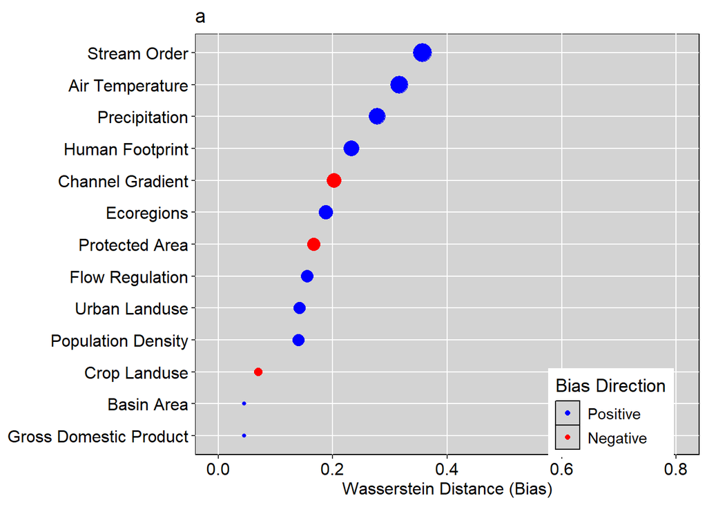

Figure 1: [Wasserstein Distance](https://www.sciencedirect.com/topics/mathematics/wasserstein-distance) of the 13 selected variables.

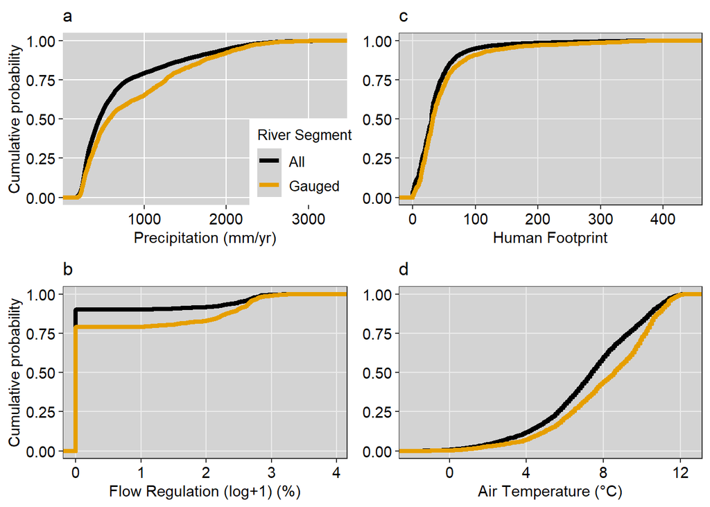

Figure 2: variable distributions showing cumulative probabilities of variables occurrence.

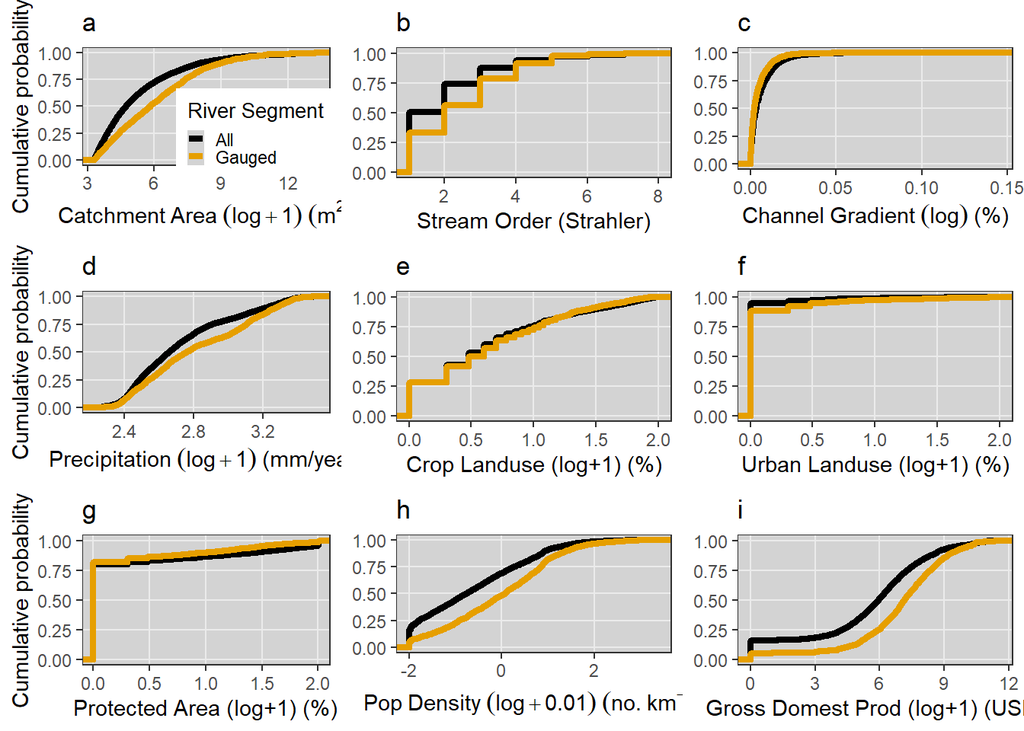

Figure 2: variable distributions showing cumulative probabilities of variables occurrence.

*Installing New Gage*

The next step is selecting the GRADES river segment that will create the largest reduction in bias for the select variable(s) by creating a ‘simulated gage.’ Bias calculations are reworked with a ‘phantom’ gage assigned to each successive ungaged segment in each loop. The segment that produces the largest reduction in bias to the select variable(s) is highlighted below in red with adjacent river sections. Each GRADES segment has an associated COMID that identifies segment length, the parent river section, and geospatial information.

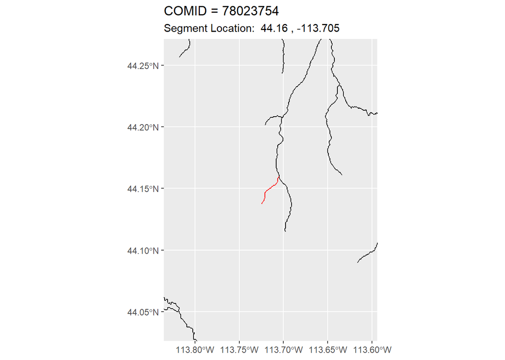

Figure 3: GRADES river segment that minimizes variable(s) bias plotted with adjacent segments and geospatial information.

[interactive chart not shown]

Figure 4: GRADES river segment overlaid on satellite imagery

# Bias Test

Water BSU

*Gage Placement Bias: Testing pre_mm_cyr | 2024-06-20*

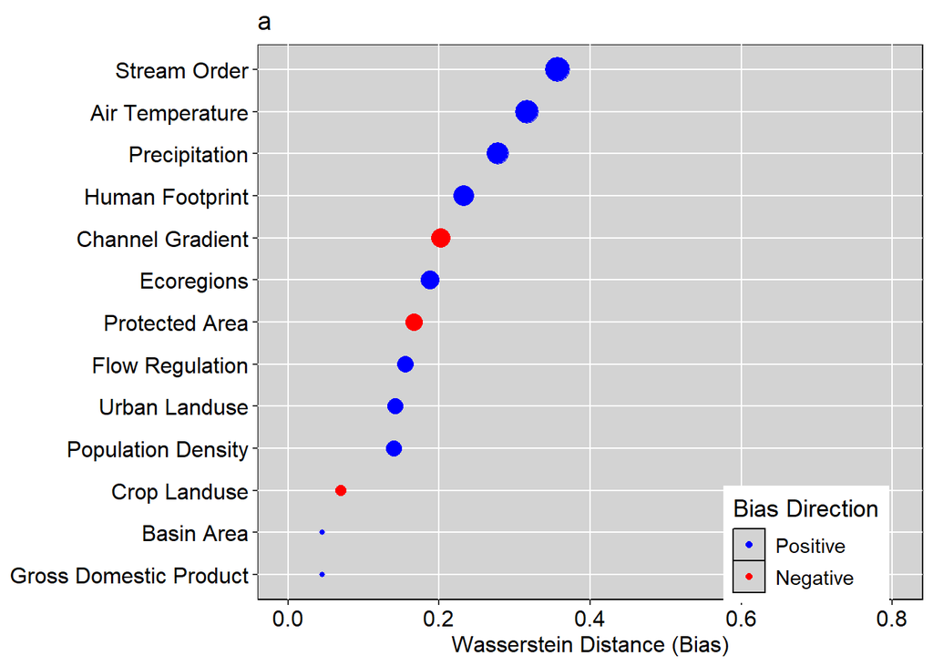

Figure 1: [Wasserstein Distance](https://www.sciencedirect.com/topics/mathematics/wasserstein-distance) of the 13 selected variables.

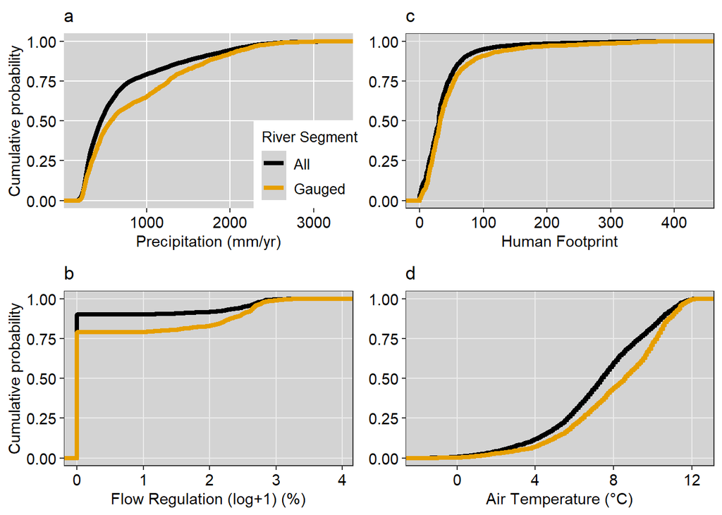

Figure 2: variable distributions showing cumulative probabilities of variables occurrence.

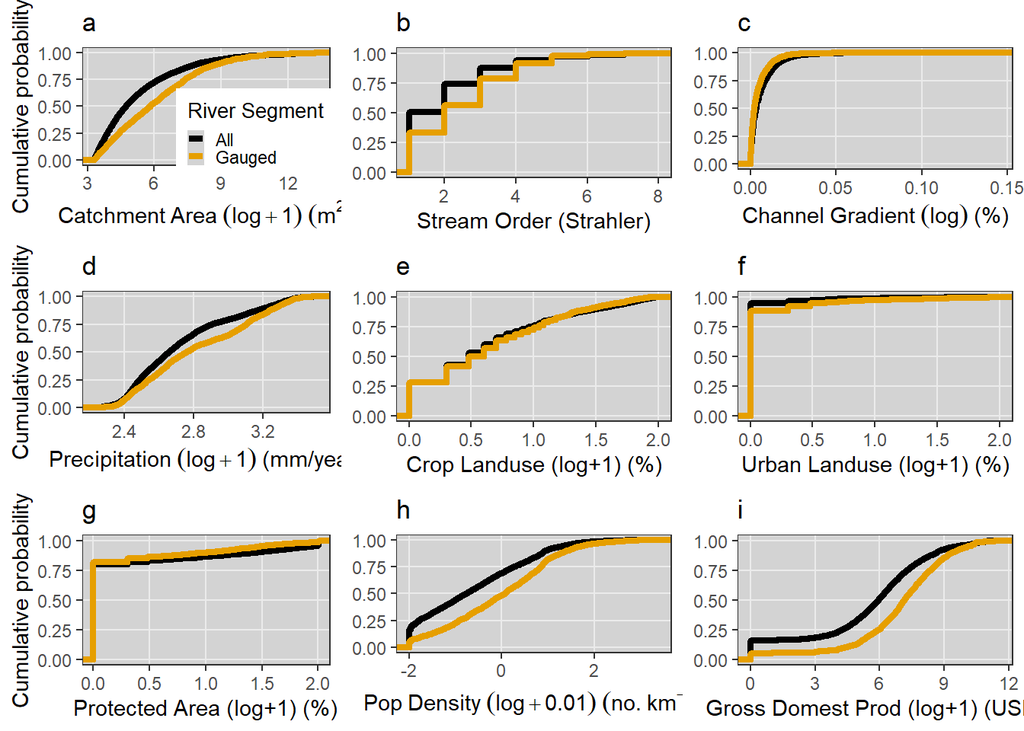

Figure 2: variable distributions showing cumulative probabilities of variables occurrence.

*Installing New Gage*

The next step is selecting the GRADES river segment that will create the largest reduction in bias for the select variable(s) by creating a ‘simulated gage.’ Bias calculations are reworked with a ‘phantom’ gage assigned to each successive ungaged segment in each loop. The segment that produces the largest reduction in bias to the select variable(s) is highlighted below in red with adjacent river sections. Each GRADES segment has an associated COMID that identifies segment length, the parent river section, and geospatial information.

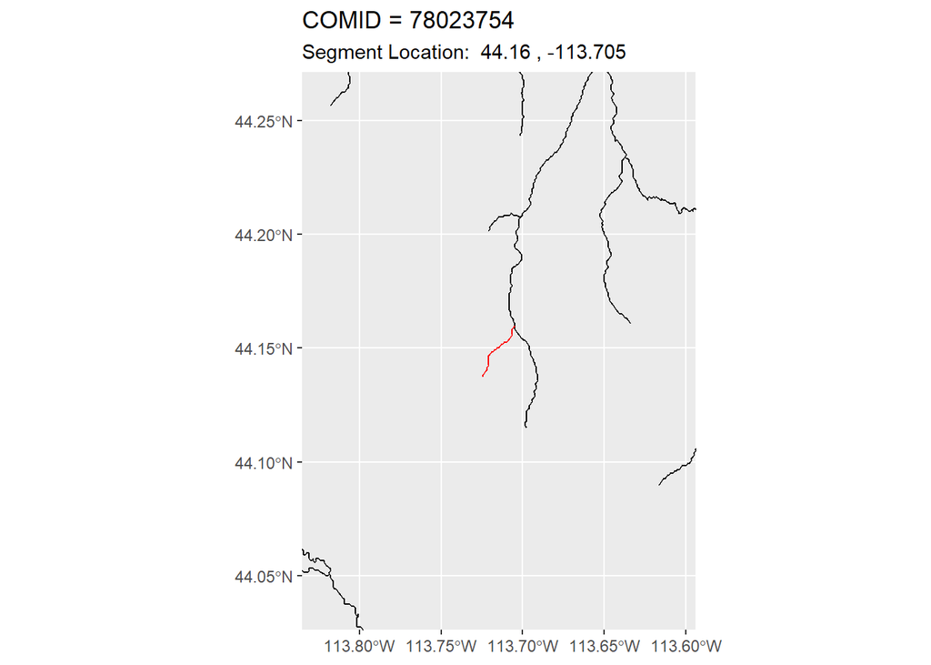

Figure 3: GRADES river segment that minimizes variable(s) bias plotted with adjacent segments and geospatial information.

[interactive chart not shown]

Figure 4: GRADES river segment overlaid on satellite imagery